# Families

2020-02-07

### 0.0.1 Document History

Original Publish Date: 21 July, 2020

Updated on: 10:08 PM – 03 August, 2021

In this post we further analyse the families. We categorised them into two - declining and rising. We track down all the families started in 1970s till 2007. Then we assess their performance in the elections held after 2007. This includes 3 General elections and 2 Assembly elections. If they have one at least one election in these 5 elections we call them rising dynasties and rest of them as declining dynasties.

# 1 Summary Stats

## 1.1 Elite types

### 1.1.1 Definitions

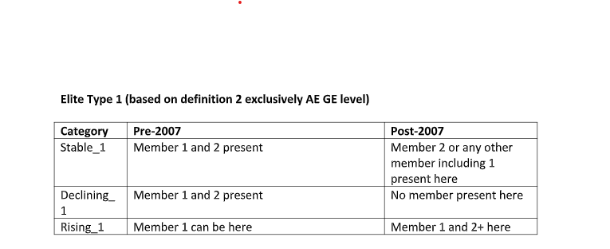

### 1.1.2 Break-up of elite categories

| success_cat | count |
| --- | --- |
| Declining | 90 |
| Rising | 122 |
| Stable | 110 |

### 1.1.3 turncoats and same party

| election_type | success_cat | turncoat | same_party |
| --- | --- | --- | --- |
| AE | Declining | 0.22 | 0.50 |
| AE | Rising | 0.20 | 0.54 |
| AE | Stable | 0.23 | 0.54 |
| GE | Declining | 0.18 | 0.62 |
| GE | Rising | 0.23 | 0.52 |
| GE | Stable | 0.18 | 0.72 |

### 1.1.4 delim change

```
## # A tibble: 4 x 4
## # Groups:   delim [2]
##   delim    constituency_type count total
##   <chr>    <chr>             <int> <int>
## 1 diss/new GEN                  16    18
## 2 diss/new SC                    2    18
## 3 old      GEN                 302   385
## 4 old      SC                   83   385
```

### 1.2.1 A note on the life span metric

Life span is a metric that measures the years that a family or politicains have been active in politcs. Since our dynasty data data starts from 1974 and ends with politicinas who are in term till 2024, this duration of period will start from 2/3/5/6 and end at 50 years. So within this period, the maximum life span that a family can have is 50 years.

In simple words, this metric checks if a politician or a family was active ina certain year and adds up that year. We binary value is given to every year that is 1 for someone’s presence and 0 otherwise. Here we have to note that, we do not consider how many members are present at a time rather we just consider that the family was active in that particular year.

We define active in politics as being either runner-up or winner that election. Few examples:

- Politician A contested in 1974, 2002 and his son contested in 2017. The life span of this family would be 15 years. See that we add a value of one for each year they are in power.
- A politician and his wife contested together in 2012 and later on his wife resigned from assembly and contested in 2014 Loksabha election. In this case, this family’s life span would be 7 years

**This metric also have some flaws, some of them are;**

- this does not diffrentiate between a winner and runner-up
- this does not compensate for the years in which multiple members are cotesting together.

### 1.2.2 Ownership of edu categories wrt elite categories

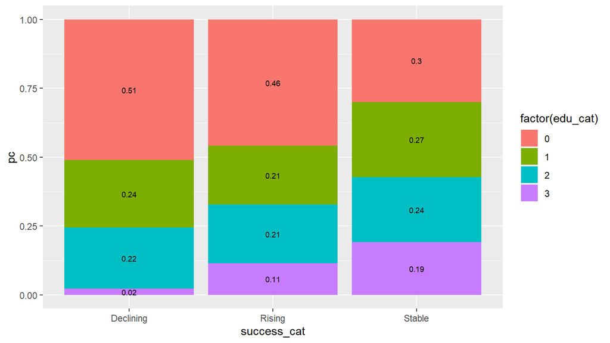

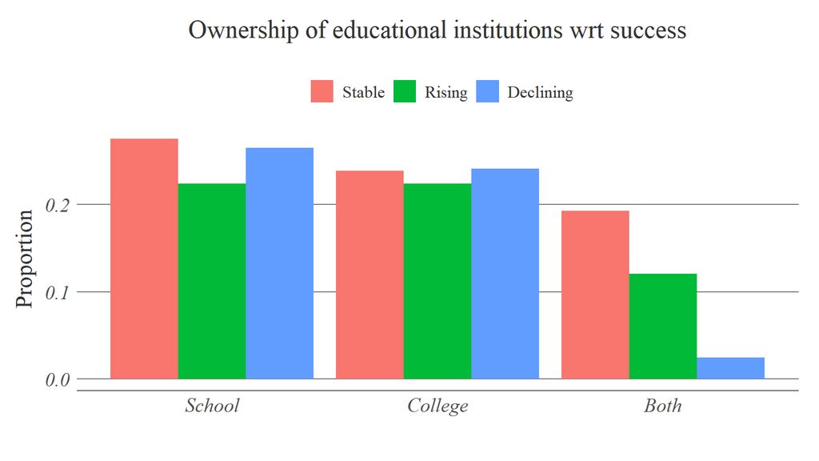

### 1.2.3 Land wrt elite cat. and caste

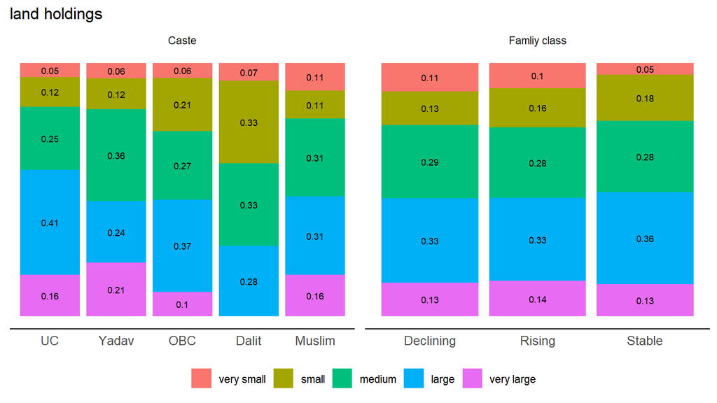

| success_cat | mean(land, na.rm = TRUE, trim = 0.05) |
| --- | --- |
| Declining | 259.8780 |
| Rising | 269.5455 |
| Stable | 287.3000 |

### 1.2.4 Industries

In first two tabs we look at the proportion of entities within that category who owns a specific business.

How it’s done:

In the manipulated dataset every business is coded as a binary variable. Take the case of petrol pumps(`ind_c1`), that entities column will be marked as `1` if they own a petrol pump, `0` otherwise.

To calculate the proportion of entities that own a specific business, we calculate the mean of that variable for all unique observations in that group.

#### 1.2.4.1 fam v/s non-fam

| Industries | % of owners among fam | % of owners among Non- fam |
| --- | --- | --- |
| Petrol Pumps | 0.46 | 0.12 |
| Construction & Transport | 0.43 | 0.18 |
| Brick klin and Sand mining | 0.27 | 0.08 |
| Agri business | 0.07 | 0.11 |
| Shops and showrooms | 0.05 | 0.03 |
| Small Business | 0.38 | 0.43 |
| Unknown | 0.04 | 0.40 |

#### 1.2.4.2 Stable v/s declining

##### 1.2.4.2.1 prev

| Industries | % of owners among stable families | % of owners among declining families |
| --- | --- | --- |
| Petrol Pumps | 0.58 | 0.34 |
| Construction & Transport | 0.46 | 0.34 |
| Brick klin and Sand mining | 0.35 | 0.18 |
| Agri business | 0.06 | 0.04 |
| Shops and showrooms | 0.06 | 0.06 |
| Small Business | 0.29 | 0.50 |
| Unknown | 0.01 | 0.08 |

##### 1.2.4.2.2 Invereted

| family class | Petrol Pumps | Construction & Transport | Brick klin and Sand mining | Agri business | Shops and showrooms | Small Business | Unknown |
| --- | --- | --- | --- | --- | --- | --- | --- |
| Stable | 0.67 | 0.62 | 0.71 | 0.64 | 0.58 | 0.42 | 0.12 |
| Declining | 0.33 | 0.38 | 0.29 | 0.36 | 0.42 | 0.58 | 0.88 |

#### 1.2.4.3 Count

Industry ownership

| Politician’s identity | Average number of ownersip |
| --- | --- |
| Declining | 1.26 |
| Rising | 1.67 |
| Stable | 1.88 |

#### 1.2.4.4 rent

industry ownership wrt rent extraction type

| Politician’s identity | rent-type | Proportion |
| --- | --- | --- |
| Declining | non-rent-thick | 0.55 |
| Declining | rent-thick | 0.45 |
| Stable | non-rent-thick | 0.31 |
| Stable | rent-thick | 0.69 |

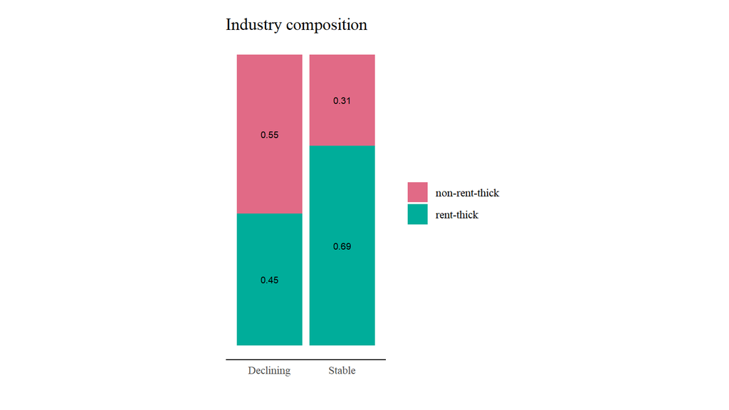

### 1.2.5 variable sumamry

| Success | land | industires | N_minister | Minister duration (months) | school | college |
| --- | --- | --- | --- | --- | --- | --- |
| Declining | 275.67 | 1.26 | 0.43 | 9.37 | 0.27 | 0.24 |
| Rising | 292.21 | 1.67 | 0.65 | 20.07 | 0.33 | 0.33 |
| Stable | 306.64 | 1.88 | 0.72 | 26.73 | 0.46 | 0.43 |

### 1.2.6 political diversification wrt family class

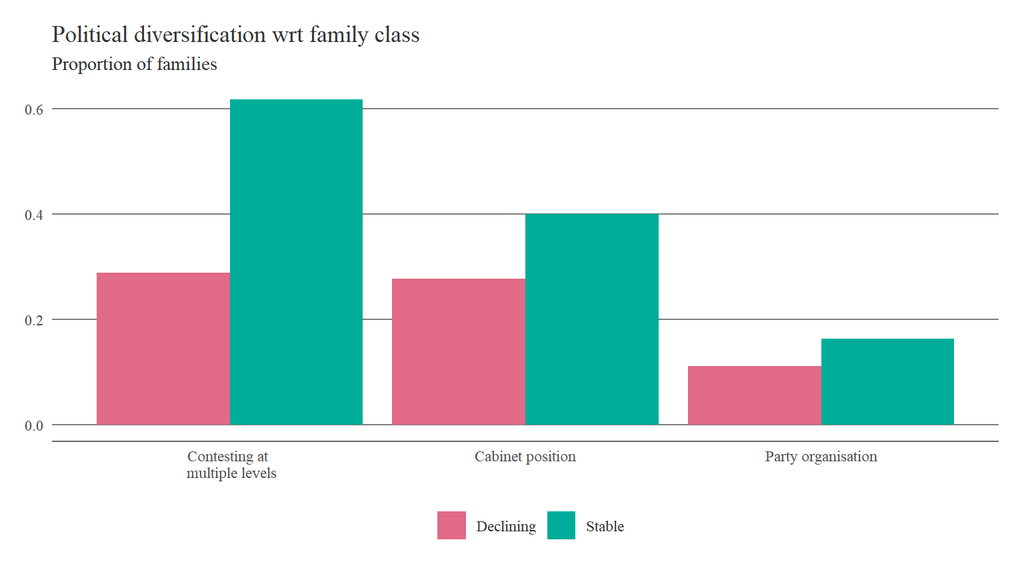

### 1.2.7 political diversification wrt caste

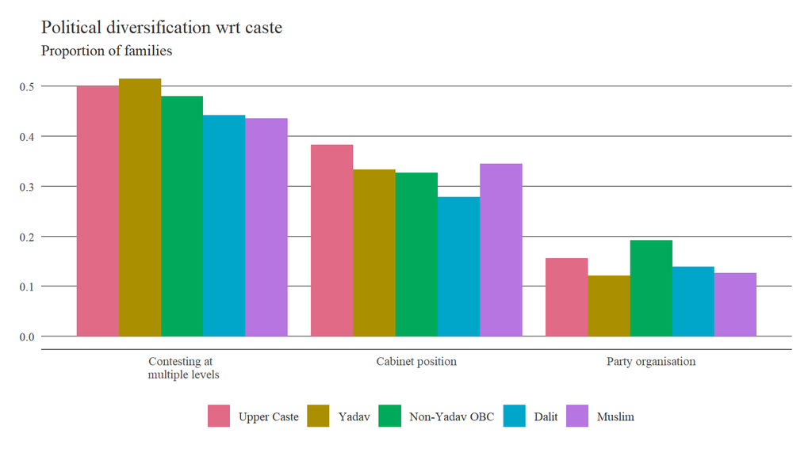

`Rising` category not included.

#### 1.2.8.1 caste - pol & econ div

**wrt caste groups**

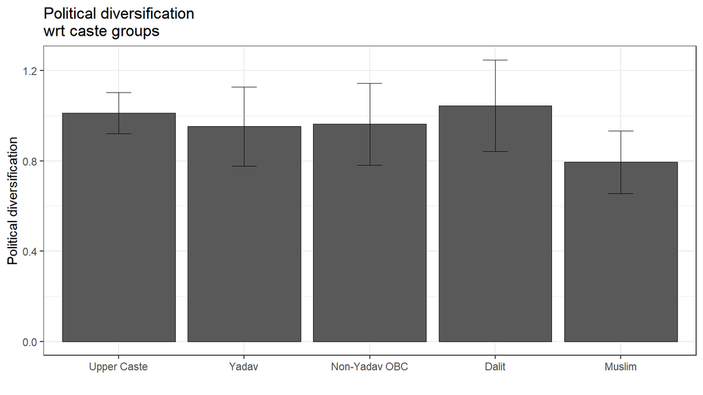

**econ div**

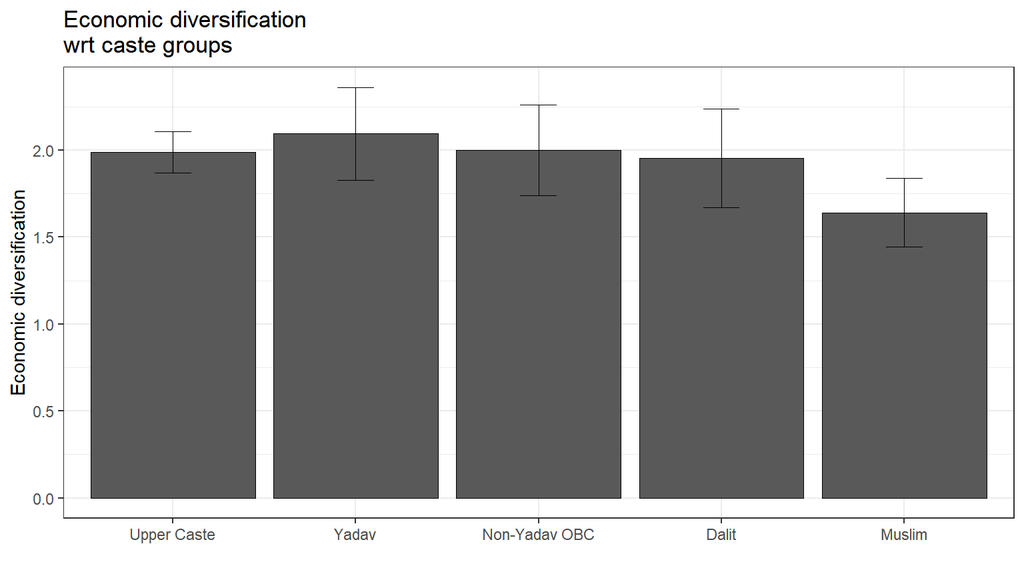

## 1.3 Life span

### 1.3.1 wrt success cats

Average life span

| Success | Life span |
| --- | --- |
| Declining | 19 |
| Rising | 22 |
| Stable | 33 |

### 1.3.2 life span graphs

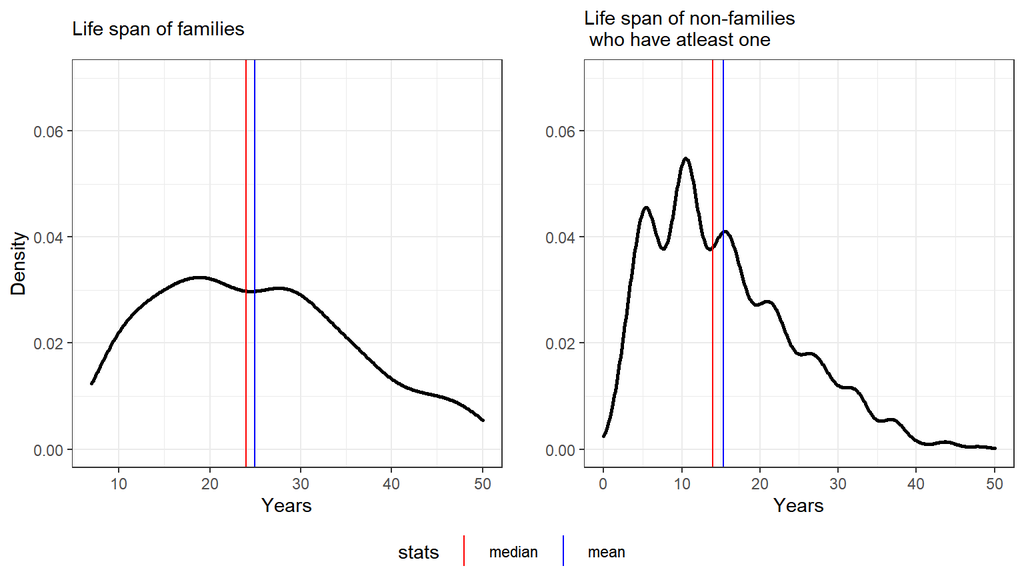

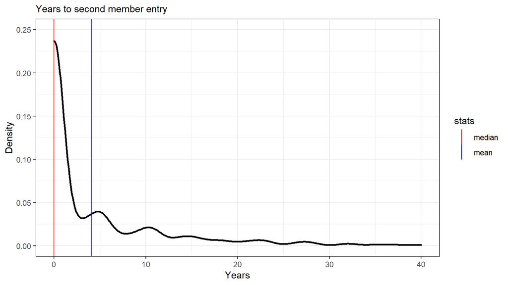

### 1.3.3 life span regression

$${Life \ span \ of \ family} = \alpha +\beta_{1}Political \ diversification {_i} + \beta_{2} Economic \ diversification{_i} + \\ \beta_{3}Land \ ownership{_i} + \beta_{4} Years \ to \ second \ member \ entry{_i} + \\ \beta_{5} Election \ won \ by \ first\ member{_i} + Z + \epsilon$$

|  | *Dependent variable:* |
| --- | --- |
|  | fam_life |
| Political diversification | 1.799*** |
|  | (0.507) |
| Economic diversification | 1.439*** |
|  | (0.363) |
| Land ownership | -0.450 |
|  | (0.391) |
| Years to second member entry | -0.153** |
|  | (0.060) |
| Elections won by founder | 3.509*** |
|  | (0.257) |
| Caste control | Yes |
| Decade control | Yes |
| Observations | 322 |
| R<sup>2</sup> | 0.570 |
| Adjusted R<sup>2</sup> | 0.550 |
| Residual Std. Error | 7.260 (df = 307) |
| *Note:* | p<0.1; p<0.05; p<0.01 |

### 1.3.4 family formation

| yar | prop |
| --- | --- |
| 2009 | 0.07 |
| 2012 | 0.41 |
| 2014 | 0.06 |
| 2017 | 0.42 |
| 2019 | 0.05 |

## 1.4 caste

### 1.4.1 caste composition

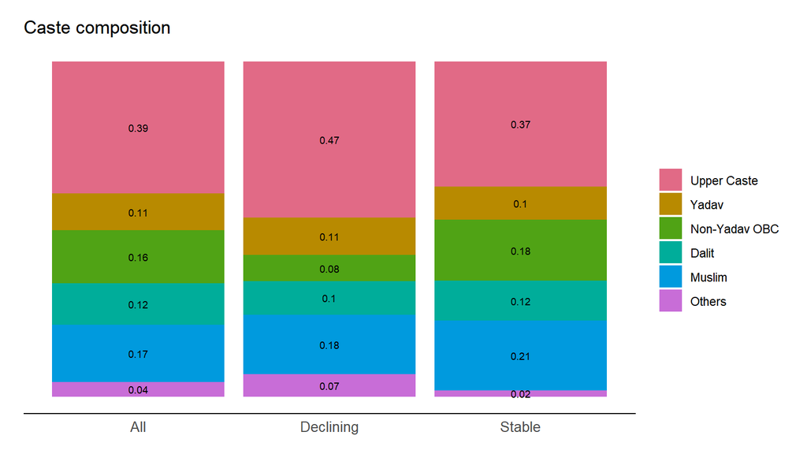

### 1.4.2 economic diversification

| caste_groups | mean | median |
| --- | --- | --- |
| Upper Caste | 2.00 | 2 |
| Yadav | 2.15 | 2 |
| Non-Yadav OBC | 1.96 | 2 |
| Dalit | 1.74 | 2 |
| Muslim | 1.69 | 2 |

### 1.4.3 Land

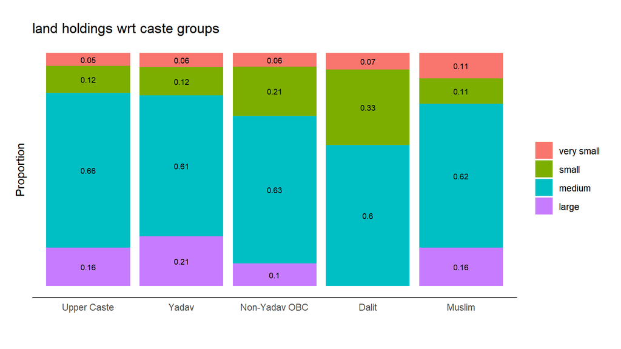

### 1.4.4 land fam

| land_cat | success_cat | count | pc |
| --- | --- | --- | --- |
| small | Declining | 18 | 0.42 |
| small | Stable | 25 | 0.58 |
| medium | Declining | 26 | 0.47 |
| medium | Stable | 29 | 0.53 |
| large | Declining | 29 | 0.42 |
| large | Stable | 40 | 0.58 |
| very large | Declining | 11 | 0.44 |
| very large | Stable | 14 | 0.56 |

### 1.4.5 Life span wrt caste

| caste_groups | mean | median |
| --- | --- | --- |
| Dalit | 25 | 23 |
| Muslim | 25 | 26 |
| Non-Yadav OBC | 26 | 26 |
| Others | 19 | 20 |
| Upper Caste | 24 | 23 |
| Yadav | 27 | 26 |

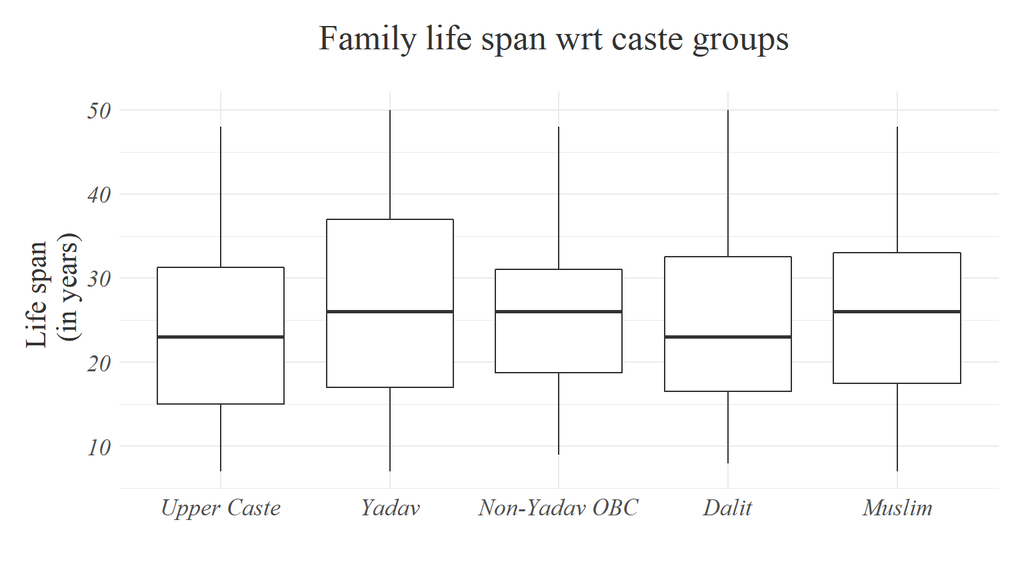

# 2 ADR

## 2.1 assets

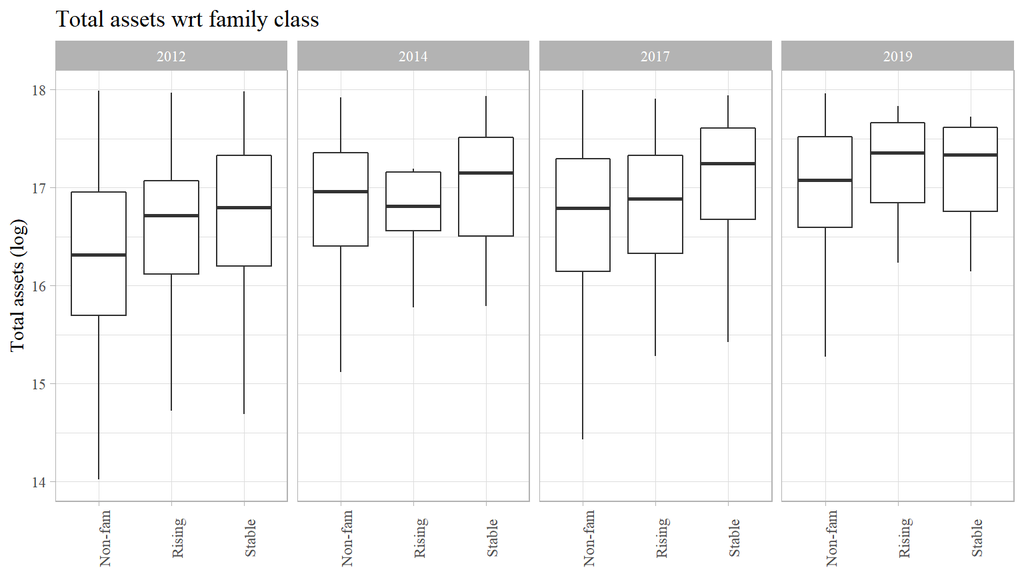

## 2.2 movable+ immovable - stacked

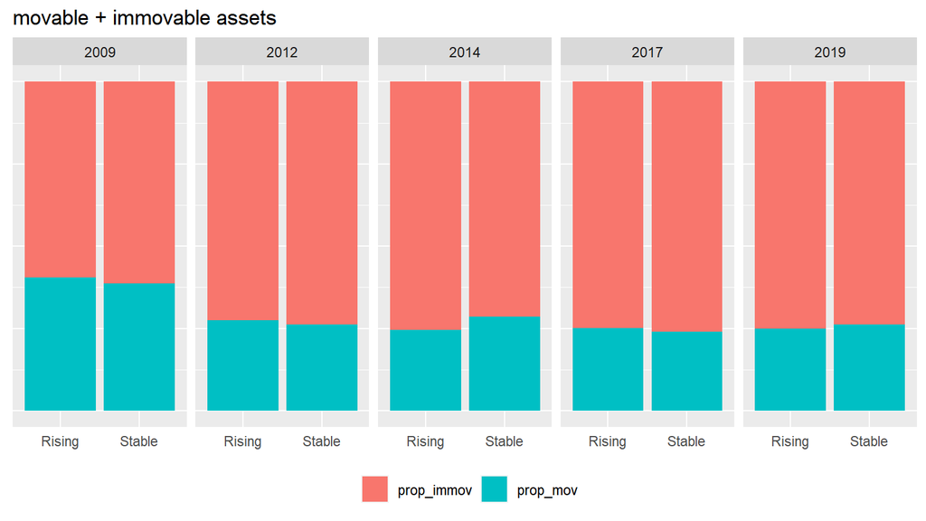

## 2.3 criminaltiy

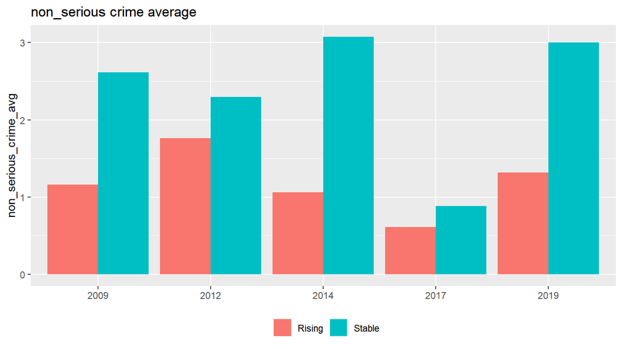

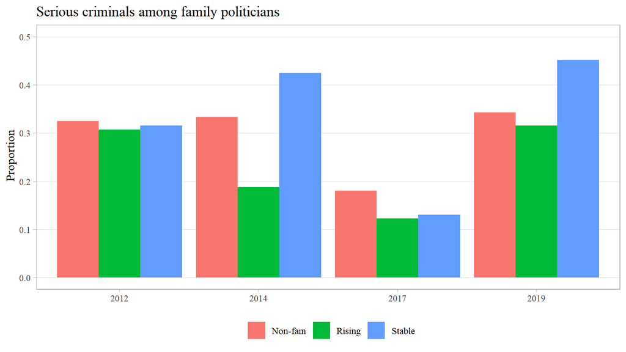

# 3 Regressions

## 3.1 Multinom.

### 3.1.1 Declining ref.

$$\left(logit \right){Political \ family \ class} = \alpha +\beta_{1}Political \ diversification {_i} + \beta_{2} Economic \ diversification{_i} + \\ \beta_{3}Land \ ownership{_i} + Z + \epsilon$$

|  | *Dependent variable:* |  |
| --- | --- | --- |
|  | Stable | Rising |
|  | (1) | (2) |
| Political diversification | 0.669*** | 0.490*** |
|  | (0.189) | (0.183) |
| Economic diversification | 0.548*** | 0.284** |
|  | (0.142) | (0.136) |
| Land ownership | -0.174 | -0.122 |
|  | (0.147) | (0.139) |
| Caste control | Yes | Yes |
| Akaike Inf. Crit. | 688.287 | 688.287 |
| *Note:* | p<0.1; p<0.05; p<0.01 |  |

### 3.1.2 Stable ref.

|  | *Dependent variable:* |  |
| --- | --- | --- |
|  | Rising | Declining |
|  | (1) | (2) |
| Political diversification | -0.180 | -0.669*** |
|  | (0.153) | (0.189) |
| Economic diversification | -0.264** | -0.548*** |
|  | (0.120) | (0.142) |
| Land ownership | 0.051 | 0.174 |
|  | (0.130) | (0.147) |
| Caste control | Yes | Yes |
| Akaike Inf. Crit. | 688.287 | 688.287 |
| *Note:* | p<0.1; p<0.05; p<0.01 |  |

### 3.1.3 Rising ref.

|  | *Dependent variable:* |  |
| --- | --- | --- |
|  | Declining | Stable |
|  | (1) | (2) |
| Political diversification | -0.490*** | 0.180 |
|  | (0.183) | (0.153) |
| Economic diversification | -0.284** | 0.264** |
|  | (0.136) | (0.120) |
| Land ownership | 0.122 | -0.051 |
|  | (0.139) | (0.130) |
| Caste control | Yes | Yes |
| Akaike Inf. Crit. | 688.287 | 688.287 |
| *Note:* | p<0.1; p<0.05; p<0.01 |  |

## 3.2 OLS

### 3.2.1 All family class: All families

|  | *Dependent variable:* |  |  |
| --- | --- | --- | --- |
|  | declining | rising | stable |
|  | (1) | (2) | (3) |
| Political diversification | -0.081*** | 0.011 | 0.069** |
|  | (0.030) | (0.033) | (0.032) |
| Economic diversification | -0.068*** | -0.007 | 0.075*** |
|  | (0.021) | (0.023) | (0.023) |
| Land ownership | 0.023 | -0.002 | -0.021 |
|  | (0.023) | (0.025) | (0.024) |
| Caste control | Yes | Yes | Yes |
| Observations | 322 | 322 | 322 |
| R<sup>2</sup> | 0.134 | 0.105 | 0.106 |
| Adjusted R<sup>2</sup> | 0.106 | 0.077 | 0.077 |
| Residual Std. Error (df = 311) | 0.425 | 0.467 | 0.456 |
| *Note:* | p<0.1; p<0.05; p<0.01 |  |  |

### 3.2.2 Declining

|  | *Dependent variable:* |
| --- | --- |
|  | Family decline |
| Political diversification | -0.124*** |
|  | (0.039) |
| Economic diversification | -0.095*** |
|  | (0.028) |
| Land ownership | 0.012 |
|  | (0.030) |
| Years to second member entry | 0.022*** |
|  | (0.007) |
| Elections won by founder | 0.007 |
|  | (0.021) |
| Caste control | Yes |
| Decadecontrol | Yes |
| Observations | 200 |
| R<sup>2</sup> | 0.291 |
| Adjusted R<sup>2</sup> | 0.242 |
| Residual Std. Error | 0.434 (df = 186) |
| *Note:* | p<0.1; p<0.05; p<0.01 |

## 3.3 summary

Summary of family data

| Measure | Elite catagory | Political diversification | Minister duration(Months) | Economic diversification | Land ownership(Deciles) | Years for second member |
| --- | --- | --- | --- | --- | --- | --- |
| Length | Declining | 90.00 | 90.00 | 90.00 | 90.00 | 90.00 |
| Length | Rising | 122.00 | 122.00 | 122.00 | 122.00 | 122.00 |
| Length | Stable | 110.00 | 110.00 | 110.00 | 110.00 | 110.00 |
| Unique-N | Declining | 2.00 | 25.00 | 4.00 | 5.00 | 18.00 |
| Unique-N | Rising | 2.00 | 32.00 | 4.00 | 5.00 | 25.00 |
| Unique-N | Stable | 2.00 | 31.00 | 4.00 | 5.00 | 15.00 |
| Mean | Declining | 0.04 | 4.49 | 1.26 | 3.24 | 7.21 |
| Mean | Rising | 0.18 | 9.93 | 1.67 | 3.25 | 10.53 |
| Mean | Stable | 0.17 | 10.53 | 1.88 | 3.35 | 5.35 |
| SD | Declining | 0.21 | 10.55 | 1.01 | 1.18 | 5.18 |
| SD | Rising | 0.39 | 17.72 | 1.02 | 1.18 | 9.88 |
| SD | Stable | 0.38 | 17.90 | 0.92 | 1.06 | 4.19 |
| Min | Declining | 0.00 | 0.00 | 0.00 | 1.00 | 0.00 |
| Min | Rising | 0.00 | 0.00 | 0.00 | 1.00 | 0.00 |
| Min | Stable | 0.00 | 0.00 | 0.00 | 1.00 | 0.00 |
| Max | Declining | 1.00 | 54.00 | 3.00 | 5.00 | 25.00 |
| Max | Rising | 1.00 | 78.50 | 3.00 | 5.00 | 43.00 |
| Max | Stable | 1.00 | 86.00 | 3.00 | 5.00 | 22.00 |

# 4 survival analysis 00

You might note that there are only 200 families in the survival analysis. This is because of the fact that, a main proponent of the survival analysis the variable dead which tells you which all families still alive or not.

In our analysis, we have decided to consider families that are not active for last 10 year (2009-2019) as no longer alive. Hence we can only include families that have at least entered before 2009. As you would know, a huge chunk of entities only formed families post delimitation, so that leaves out ~122 families from the survival analysis.

## 4.1 Base survival plots

### 4.1.1 all entities

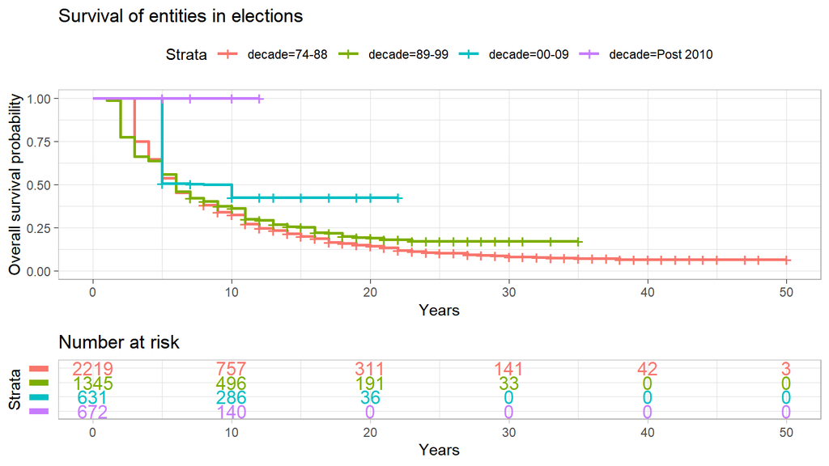

### 4.1.2 won

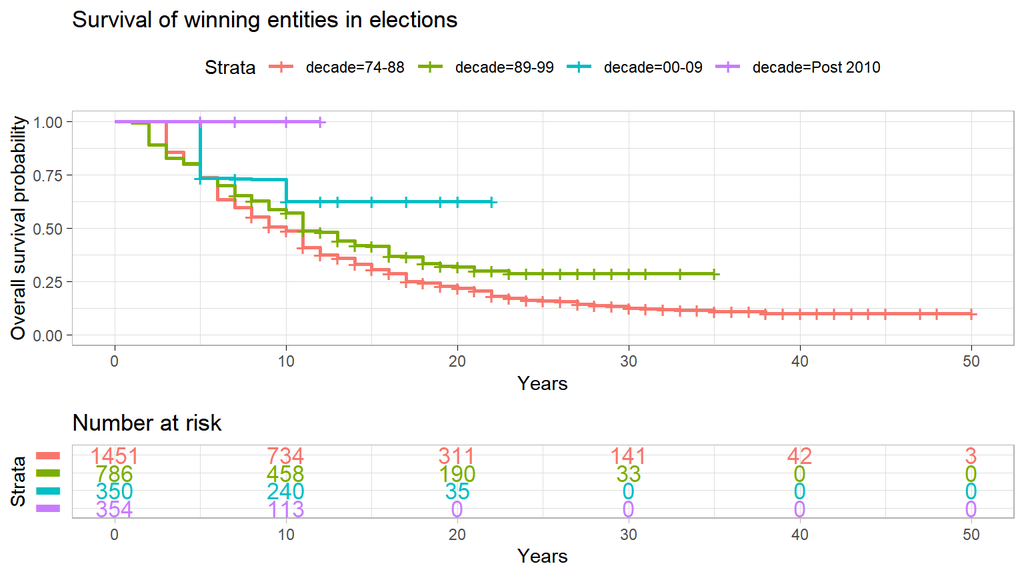

### 4.1.3 all fam

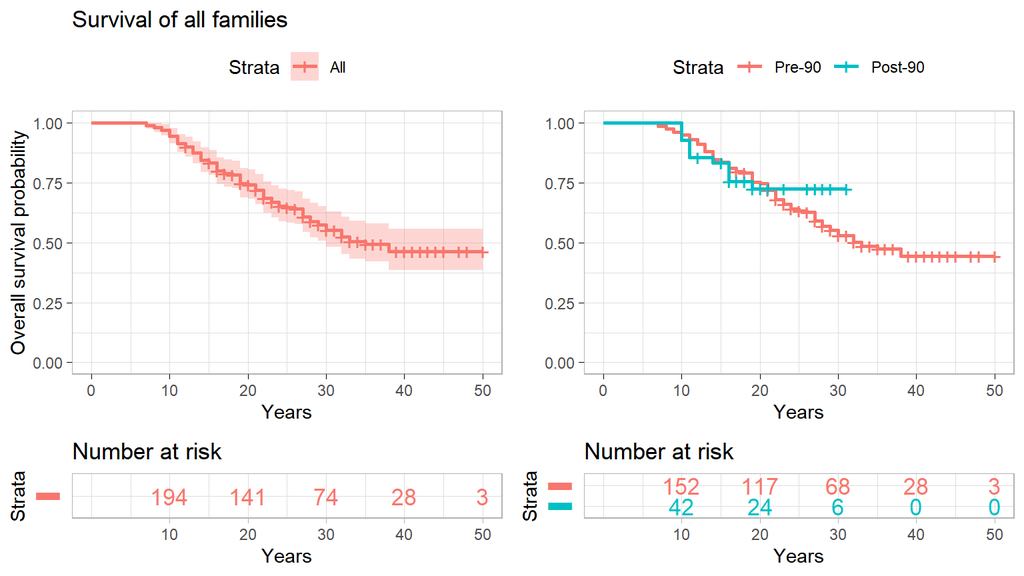

### 4.1.4 after became fam

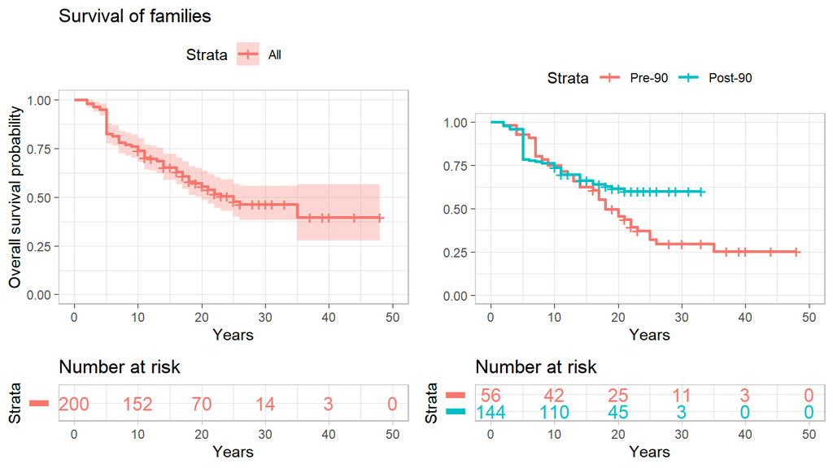

### 4.1.5 Econ diversification grid

combination of education and industry

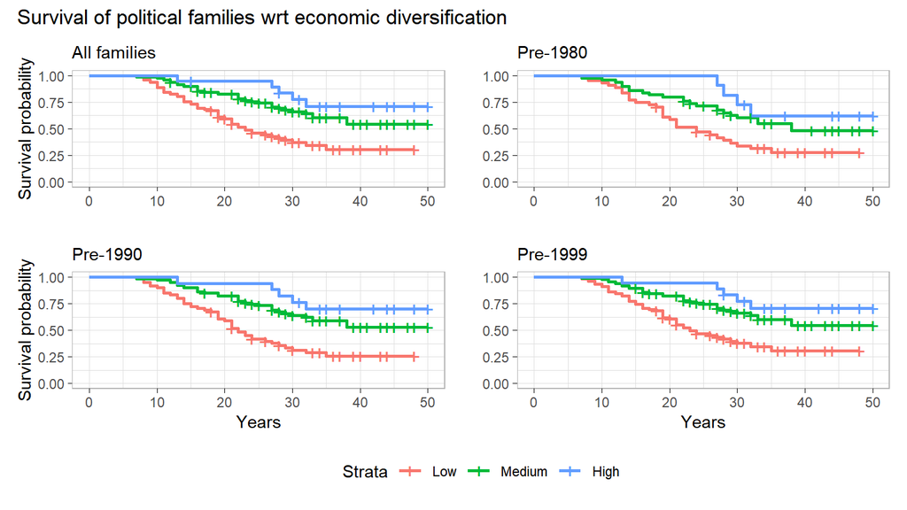

### 4.1.6 pol diversification grid

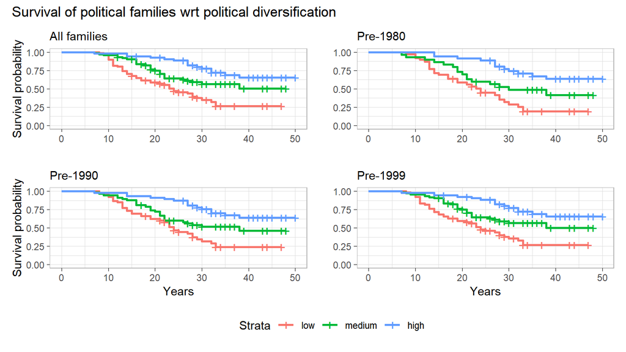

## 4.2 coax -proportional hazard regression

**Coax hazard regression**

|  | *Dependent variable:* |
| --- | --- |
|  | Family decline |
| Political diversification | -0.608*** |
|  | (0.202) |
| Economic diversification | -0.454*** |
|  | (0.105) |
| Land ownership | 0.047** |
|  | (0.022) |
| Years to second member entry | 0.051 |
|  | (0.099) |
| Elections won by founder | -0.306*** |
|  | (0.087) |
| Caste control | Yes |
| Observations | 200 |
| R<sup>2</sup> | 0.326 |
| Max. Possible R<sup>2</sup> | 0.988 |
| Log Likelihood | -399.137 |
| Wald Test | 64.500*** (df = 11) |
| LR Test | 78.845*** (df = 11) |
| Score (Logrank) Test | 71.808*** (df = 11) |
| *Note:* | p<0.1; p<0.05; p<0.01 |

## 4.3 year entry sensitivity

**Coax hazard regression**

|  | *Dependent variable:* |  |  |
| --- | --- | --- | --- |
|  | Family decline |  |  |
|  | (1) | (2) | (3) |
| Political diversification | -0.646*** | -0.636* | -2.300*** |
|  | (0.206) | (0.350) | (0.804) |
| Economic diversification | -0.476*** | -0.654*** | -1.357*** |
|  | (0.103) | (0.198) | (0.526) |
| Land ownership | -0.003 | -0.045 | -0.076 |
|  | (0.018) | (0.044) | (0.099) |
| Years to second member entry | 0.111 | 0.098 | 0.504* |
|  | (0.099) | (0.181) | (0.294) |
| Elections won by founder | -0.463*** | -0.515*** | -1.210*** |
|  | (0.086) | (0.155) | (0.415) |
| Start | All | Post 80 | Post 90 |
| Caste control | Yes | Yes | Yes |
| Decade control | Yes | Yes | Yes |
| Observations | 322 | 188 | 121 |
| R<sup>2</sup> | 0.280 | 0.230 | 0.266 |
| Max. Possible R<sup>2</sup> | 0.947 | 0.816 | 0.650 |
| Log Likelihood | -421.184 | -134.520 | -44.914 |
| Wald Test (df = 12) | 82.490*** | 42.230*** | 21.580** |
| LR Test (df = 12) | 105.636*** | 49.109*** | 37.370*** |
| Score (Logrank) Test (df = 12) | 92.773*** | 45.822*** | 26.884*** |
| *Note:* | p<0.1; p<0.05; p<0.01 |  |  |

## 4.4 Censoring sensitivity

- In this section we provide three different cut off to assess whether a family is dead or not. for eg: If a family is not has to been contesting in last x years we would consider them as dead. The number of families included in the model also change according to the cut-off because we can only include the family that has formed on or before the cut off years. The break up looks like this:

| Cut off | 5 years (2014) | 10 years (2009) | 15 years (2004) | 20 years (1999) |
| --- | --- | --- | --- | --- |
| alive | 128 | 110 | 91 \| | 88 |
| dead | 130 | 90 | 65 \| | 31 |
| total | 258 | 200 | 156 \| | 119 |

**Coax hazard regression**

|  | DV: Family decline |  |  |  |
| --- | --- | --- | --- | --- |
|  | (1) | (2) | (3) | (4) |
| Political diversification | -0.553*** | -0.332** | -0.621** | -0.655* |
|  | (0.196) | (0.152) | (0.250) | (0.385) |
| Economic diversification | -0.452*** | -0.354*** | -0.444*** | -0.637*** |
|  | (0.103) | (0.084) | (0.123) | (0.184) |
| Land ownership | 0.037* | 0.051*** | 0.021 | -0.066 |
|  | (0.022) | (0.016) | (0.026) | (0.048) |
| Years to second member entry | 0.052 | 0.037 | 0.072 | 0.152 |
|  | (0.097) | (0.082) | (0.117) | (0.159) |
| Elections won by founder | -0.318*** | -0.344*** | -0.297*** | -0.258 |
|  | (0.086) | (0.068) | (0.111) | (0.188) |
| Cut-off years | 2009 | 2014 | 2004 | 1999 |
| Caste control | Yes | Yes | Yes | Yes |
| Decade control | Yes | Yes | Yes | Yes |
| Observations | 200 | 258 | 156 | 119 |
| R<sup>2</sup> | 0.331 | 0.318 | 0.297 | 0.282 |
| Max. Possible R<sup>2</sup> | 0.989 | 0.995 | 0.980 | 0.910 |
| Log Likelihood | -412.742 | -645.460 | -279.591 | -123.745 |
| Wald Test (df = 12) | 66.660*** | 82.000*** | 46.030*** | 25.150** |
| LR Test (df = 12) | 80.492*** | 98.618*** | 55.036*** | 39.467*** |
| Score (Logrank) Test (df = 12) | 73.470*** | 90.355*** | 51.156*** | 31.560*** |
| *Note:* | p<0.1; p<0.05; p<0.01 |  |  |  |

## 4.5 Econ and pol diversification grid

life span variable in both plots are the ones that arecounted only after they ebcame a family.

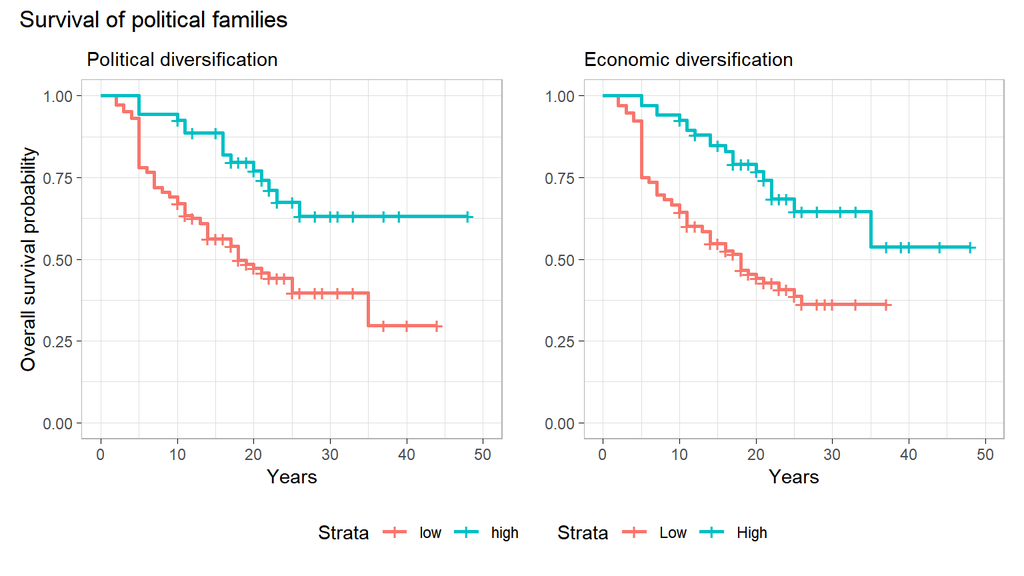